# eltec_exploration

Artjoms Šeļa

4/11/2022

### Setup

```r
library(tidyverse)
library(tidytext)
```

### Getting the info in

```r
files <- list.files("booknlp_results/ENG_ELTEC/",recursive = T,full.names = T)

quotes <- files[str_detect(files,"\\.quotes")][-7] # removing Dickens for now
coref <- files[str_detect(files, "")][-7] # removing Dickens for now

novels <-list.dirs("booknlp_results/ENG_ELTEC/",recursive = F,full.names = F)[-7]
```

### Getting quotes tables

Few things to note:

- char_id `0` is I, the narrator. In `ENG18440_Disraeli` gets a lot of narrative, not direct parts in their speech (because, uh, each narrative passage can be modeled as “belonging” to I in the first-person narration. However, still weird that narrative parts are assigned as quotes)
- Recheck empty quotes (what is the source?) Note: the [Narrator], char_id `0`, characters have huge amount of quotes usually (is the whole narrative part assigned to them?)
- `ENG18460_Reynolds` - Is it a huge novel with many characters or something is terribly wrong?
- `ENG_18481_Dickens` produces 0 quote files, no quotes recognized?
- Check if current erratic paragraph handling is influencing results
- Some quotes have “None” at their positions? See `ENG18670_Ouida`

```r
## be careful about reading .quote files with quotes characters etc.
all_texts <- lapply(quotes, read.delim, quote="", fill=FALSE)


nov_list <- vector(length=length(all_texts), mode = "list")

for(t in 1:length(all_texts)) {
  x=all_texts[[t]]

  #print(quotes[t])
  #print(t)
  ## quickly getting character names, relying on char_id here
  chr_id <- x %>%
    group_by(char_id) %>%
    filter(quote != "\" \"",
           mention_start != "None") %>%
    # character names = longest string
    filter(nchar(mention_phrase) == max(nchar(mention_phrase))) %>%
    select(char_id, mention_phrase) %>%
    # deduplicate entries by id
    filter(!duplicated(char_id)) %>%
    rename(char_name = mention_phrase) %>%
    mutate(char_id = as.integer(char_id))

  nov_list[[t]] <- all_texts[[t]] %>%
    filter(quote != "\" \"",
           mention_start != "None") %>%
    mutate(book_id = novels[t],
           mention_start = as.integer(mention_start),
           mention_end = as.integer(mention_end),
           char_id = as.integer(char_id)) %>%
    left_join(chr_id, by="char_id") %>%
    as_tibble()

}

df_all_quotes <- bind_rows(nov_list)

write_tsv(df_all_quotes,"data/all_quotes_novels.tsv")
```

```r
char_speech <- df_all_quotes %>%
  group_by(book_id, char_id,char_name) %>%
  summarise(spoken=paste(quote, collapse="\n")) %>%
  ungroup()
char_tokenized <- char_speech %>%
  filter(char_id != 0) %>%
  group_by(book_id, char_id, char_name) %>%
  unnest_tokens(input = spoken, output=word,token = "words")

char_count <- char_tokenized %>% count(char_id)

write_tsv(char_tokenized,"data/char_tokenized_no_narrators.tsv")
```

### Some plots / distributions

Number of words uttered: the expected long tail

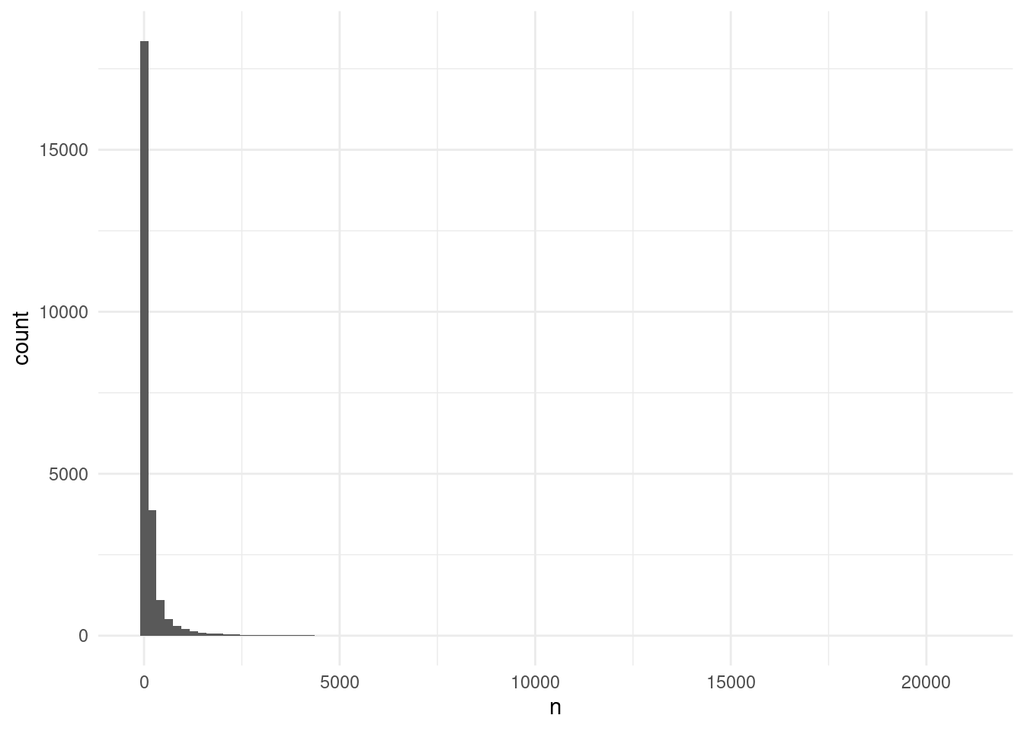

```r
char_count %>% ggplot(aes(n)) + geom_histogram(bins=100)
```

How many characters speak more than 2000 words per novel?

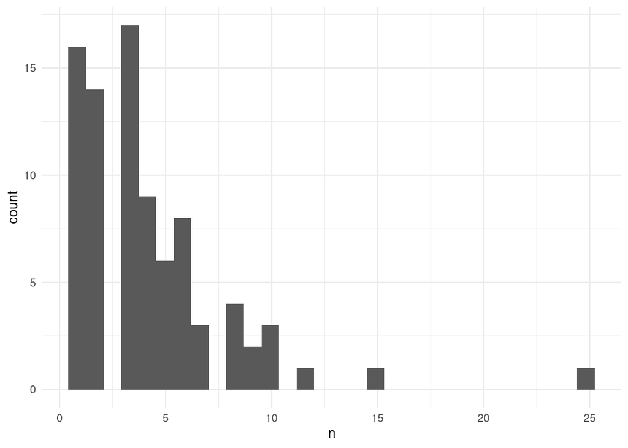

```r
char_count %>%
  filter(n > 2000) %>%
  group_by(book_id) %>%
  count(book_id) %>%
  ggplot(aes(n)) + geom_histogram()
```

```r
char_count %>%
  filter(n > 2000) %>%
  group_by(book_id) %>%
  count(book_id,sort=T) %>%
  head()
```

```
## # A tibble: 6 × 2
## # Groups:   book_id [6]
##   book_id               n
##   <chr>             <int>
## 1 ENG18460_Reynolds    25
## 2 ENG18530_Dickens     15
## 3 ENG18560_Yonge       12
## 4 ENG18650_Trollope    10
## 5 ENG18721_Eliot       10
## 6 ENG18741_Bulwer      10
```

There are `86` books with at least 2 characters having more than 1k words.  
There are `69` books with at least 2 characters having more than 2k words

```r
## 69
char_count %>%
  filter(n > 2000) %>%
  group_by(book_id) %>%
  count(book_id,sort=T) %>%
  filter(n>=2) %>%
  pull(book_id) %>%
  unique() %>%
  length()
```

```
## [1] 69
```